# Email Marketing: What’s the impact of subject line copy and time-sent on open and click-through rates? DRAFT

Steffen Hartleib

### Overview:

We spent 9 months testing and tweaking subjectlines of daily deal emails. We managed to keep open rates almost constant even though we trippled the number of emails we sent per day. We improved the conversion rate by 20%. Now that we have data on over 500 different marketing emails I wanted to see if there are any patterns. For example:  
Are there any words that tend to produce better open and click through rates?  
Does the weekday or the time of day matter?  
How important is the name of the artist?

```r
options(scipen=10000)

library('dplyr')
library('dplyr')
library('stringr')
library('ggplot2')
library('reshape2')
```

### Read Data

```r
setwd("/Users/steffen/Google Drive/ds_projects/subject_lines")

emails <- read.csv("data/email_campaigns_report.csv", header = TRUE, stringsAsFactors = FALSE)

products  = read.csv("data/products_export.csv", header = TRUE, stringsAsFactors = FALSE)
products$UPC = str_replace_all(products$UPC, "'","")
products$Artist = trimws(products$Artist, which = c("right"))

lines_items = read.csv("data/line_items_final_export.csv", header = TRUE, stringsAsFactors = FALSE)
pm_lines = filter(lines_items, Store_ID %in% c('1', '5693042'))
pm_line_art = inner_join(pm_lines, products, by = c("Lineitem_sku" = "UPC" ))
```

##### Create a list of artist names who’s products previously sold, along with total revenue per artist. We’ll use Total Revenue as a proxy for popularity. Assuming that more popular artists get higher open rates.

```r
artist_rank = select(pm_line_art, Artist, Lineitem_quantity, Lineitem_price)%>%
              mutate(Rev = Lineitem_quantity * Lineitem_price)%>%
              mutate(Artist = str_replace(Artist,"The ",""))%>%
              mutate(Artist = ifelse(Artist == "Bob Dylan", "Dylan", Artist))%>%
              group_by(Artist)%>%
              summarize(TL_Rev = sum(Rev))%>%
              arrange(desc(TL_Rev))

artist_rank <-mutate(artist_rank,Artist = str_replace(artist_rank$Artist,"The ",""))%>%
              mutate(Artist = ifelse(Artist == "Bob Dylan", "Dylan", Artist))%>%
              mutate(Artist = ifelse(Artist == "Rolling Stones", "Stones", Artist))%>%
              mutate(Artist = ifelse(Artist == "David Bowie", "Bowie", Artist))%>%
              mutate(Artist = ifelse(Artist == "Led Zeppelin", "Zeppelin", Artist))%>%
              mutate(Artist = ifelse(Artist == "Ozzy Osbourne", "Ozzy", Artist))%>%
              mutate(Artist = ifelse(Artist == "ACDC", "AC/DC", Artist))%>%
              mutate(Artist = ifelse(Artist == "Bruce Springsteen", "Springsteen", Artist))%>%
              mutate(Artist = ifelse(Artist == "Black Sabbath", "Sabbath", Artist))%>%
              mutate(Artist = ifelse(Artist == "Jimi Hendrix", "Hendrix", Artist))%>%
              mutate(Artist = ifelse(Artist == "Paul McCartney", "McCartney", Artist))%>%
              mutate(Artist = ifelse(Artist == "John Coltrane", "Coltrane", Artist))%>%
              mutate(Artist = ifelse(Artist == "Elvis Presley", "Elvis", Artist))%>%
              filter(Artist != "The")%>%
              filter(TL_Rev > 0)%>%
              filter(Artist != "popmarket")
head(artist_rank)
```

```
## # A tibble: 6 × 2
##        Artist   TL_Rev
##         <chr>    <dbl>
## 1     Beatles 881871.3
## 2       AC/DC 759438.5
## 3    Zeppelin 700007.4
## 4       Elvis 668938.3
## 5 Miles Davis 646247.4
## 6      Stones 605084.2
```

### Feature Engineering

##### Extract, dates, times, and key terms from subject lines, and create variables:

```r
camp <- filter(emails, sends > 100000)%>%
        select(id,last_run_date, name, subject, sends, opens, clicks)%>%
        mutate(Date = as.Date(last_run_date))

camp$date  <- as.Date(substr(camp$last_run_date,1,10))
camp$day <- as.factor(weekdays(camp$date))
camp$time <- substr(camp$last_run_date,11,25)
camp$hour <- as.numeric(substr(camp$last_run_date,12,13))
camp$or <- round(camp$opens/camp$sends,2)
camp$ctr <- round(camp$clicks/camp$sends,4)
camp$length = nchar(camp$subject)

camp$perc_off <-  str_extract(camp$subject,'..%')
camp$perc_off <- as.numeric(str_replace(camp$perc_off,'%',""))
camp$perc_off[is.na(camp$perc_off) == TRUE] <- 0

camp$amt_off <-  str_extract(camp$subject,'\\$...')
camp$amt_off <-  as.numeric(str_replace(camp$amt_off,'\\$',""))
camp$amt_off[is.na(camp$amt_off) == TRUE] <- 0

camp$off = as.numeric(grepl("Off|off|OFF",camp$subject))
camp$dis = as.numeric(grepl("Discount",camp$subject))
camp$sav = as.numeric(grepl("[S,s]avings|[S,s]ave",camp$subject))
camp$lim_ed = as.numeric(grepl('Limited Edition',camp$subject))
camp$vinyl = as.numeric(grepl('Vinyl|LP',camp$subject))
camp$box_set = as.numeric(grepl('Box Set',camp$subject))
camp$deluxe = as.numeric(grepl('Deluxe',camp$subject))
camp$exclusive = as.numeric(grepl('Exclusive',camp$subject))
camp$new = as.numeric(grepl('New',camp$subject))
camp$blow = as.numeric(grepl('Blowout',camp$subject))
camp$sale = as.numeric(grepl('Sale',camp$subject))
camp$steal = as.numeric(grepl('[S,s]teal', camp$subject))
camp$garage = as.numeric(grepl('[G,g]arage', camp$subject))
camp$surprise = as.numeric(grepl('[S,s]urprise', camp$subject))
str(camp)
```

```
## 'data.frame':    328 obs. of  31 variables:
##  $ id           : num  1127099772127 1127098226510 1127097933161 1127087279929 1127087049318 ...
##  $ last_run_date: chr  "2017-02-02T21:39:58.647Z" "2017-02-02T17:12:07.351Z" "2017-02-02T19:37:45.470Z" "2017-02-01T17:16:57.387Z" ...
##  $ name         : chr  "email | 20170202 | Posters" "email | 20170202 | Led_Zeppelin" "email | 20170202 | Prosthetic_Records" "email | 20170201 | Bob_Dylan" ...
##  $ subject      : chr  "RESTOCK ALERT: Deck Your Walls With Rare, Signed Posters from Dylan, Ozzy, The Who and More" "The Zeppelin Motherlode At Our Lowest Prices Ever!" "Highly Limited Edition \"Silver Series\" LPs from Lamb of God & More" "Bob Dylan's FIRST Triple Album On Deluxe Limited Editio…
##  $ sends        : int  189613 120903 139864 109909 101781 101866 151532 183988 125548 102298 ...
##  $ opens        : int  21152 17911 20149 18362 12437 14901 24183 29008 17895 15581 ...
##  $ clicks       : int  2203 3118 893 2147 871 3116 2427 3078 694 2668 ...
##  $ Date         : Date, format: "2017-02-02" "2017-02-02" ...
##  $ date         : Date, format: "2017-02-02" "2017-02-02" ...
##  $ day          : Factor w/ 7 levels "Friday","Monday",..: 5 5 5 7 7 7 6 6 6 6 ...
##  $ time         : chr  "T21:39:58.647Z" "T17:12:07.351Z" "T19:37:45.470Z" "T17:16:57.387Z" ...
##  $ hour         : num  21 17 19 17 20 23 21 23 19 17 ...
##  $ or           : num  0.11 0.15 0.14 0.17 0.12 0.15 0.16 0.16 0.14 0.15 ...
##  $ ctr          : num  0.0116 0.0258 0.0064 0.0195 0.0086 0.0306 0.016 0.0167 0.0055 0.0261 ...
```

[output cut: 17 more lines]

##### Looping through artist names and subject lines to add up the Total Revenue (= value) of the artists mentioned in the subject line.

```r
# list of artists names
artists = artist_rank$Artist

# initialize output variables
output = data.frame(1,2)
names(output) <-  c('artists', "value")
row = 0

# loop through subjects and check each for artist names
for(s in camp$subject) {
  a_list = c()
  a_value = 0
  row = row +1
    for(a in artists) {

      if(grepl(a,s) == TRUE){
        a_list = paste0(a_list," ",a)
        value = artist_rank$TL_Rev[artist_rank$Artist == a]
        a_value = a_value + value
   }
   else{
     a_list = a_list
     a_value = a_value
   }
    }

  if(is.null(a_list) == TRUE) {
    a_list <- ""
  }

line <-  c(a_list,a_value)
output <-  rbind(output, line)

}


# join artist name and value columns to 'camp' data frame

artist_value <- output[-1,]
camp = cbind(camp,artist_value)
camp$value = round(as.numeric(camp$value),0)
```

##### For every subject line we now have

1. a field with the artist name(s) mentioned in the subject line
2. a field with the sum of the values associated with those artists

```
##           artists     value
## 2  Dylan Who Ozzy 1104818.6
## 3        Zeppelin  700007.4
## 4     Lamb of God   5765.88
## 5           Dylan 542257.39
## 6     Moody Blues   2093.81
## 7         Beatles 881871.27
```

### Let’s Plot

#### Open Rates versus Dollar Amount Off, Percentage Off, and Artist Value:

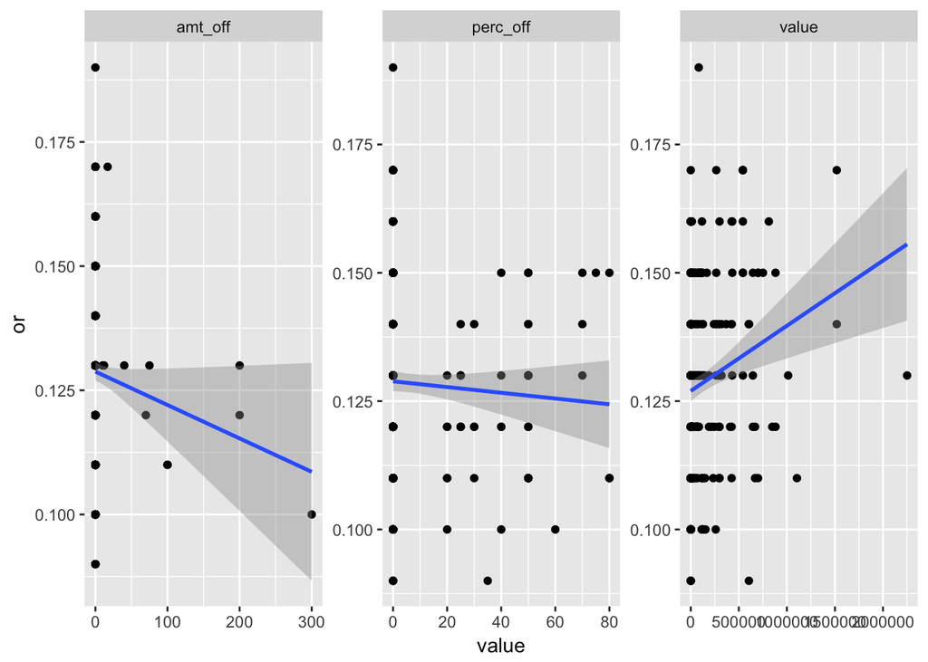

#### => Amount Off and Percentage Off seem to have a slightly negative impact or open rates - didn’t expect that.

### Click Through Rates versus Dollar Amount Off, Percent Off, and Artist Value.

##### (CTR = clicks/sends)

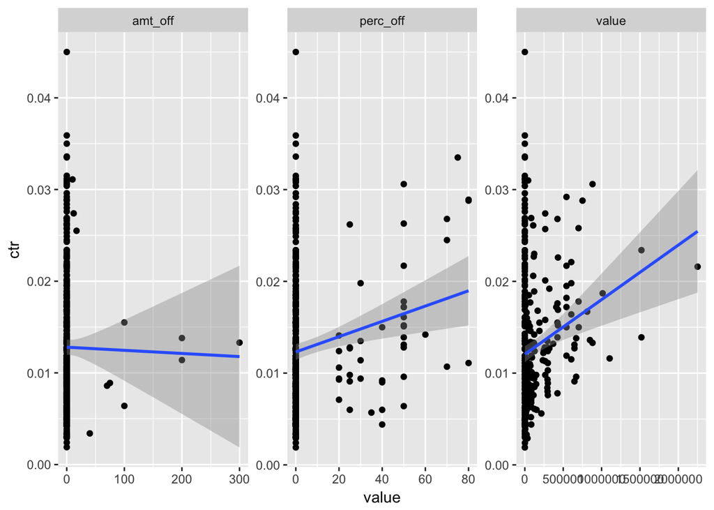

##### => Percentage Off reduces the open rate slightly, but increases the click through rate by a good amount. So the net effect looks positive.

### Open Rate versus specific terms, such as Discount, Limited, Steal …, etc.

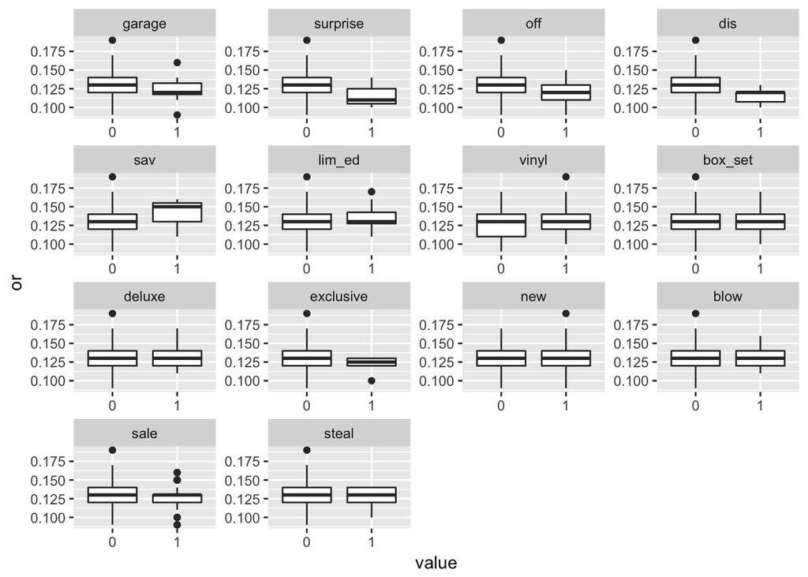

### Click Through Rate versus specific terms, such as Discount, Limited, Steal … etc.

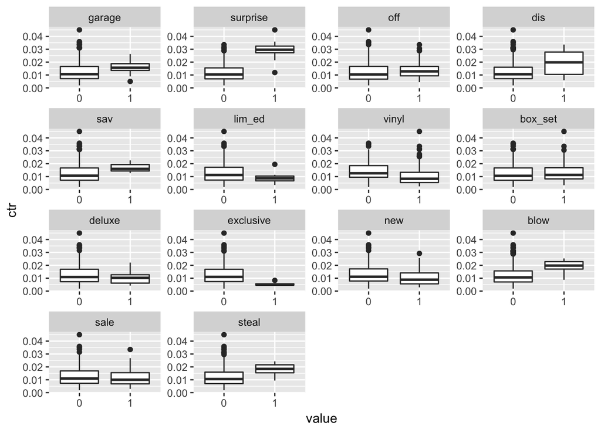

### Open and click throuh rates for days of the week

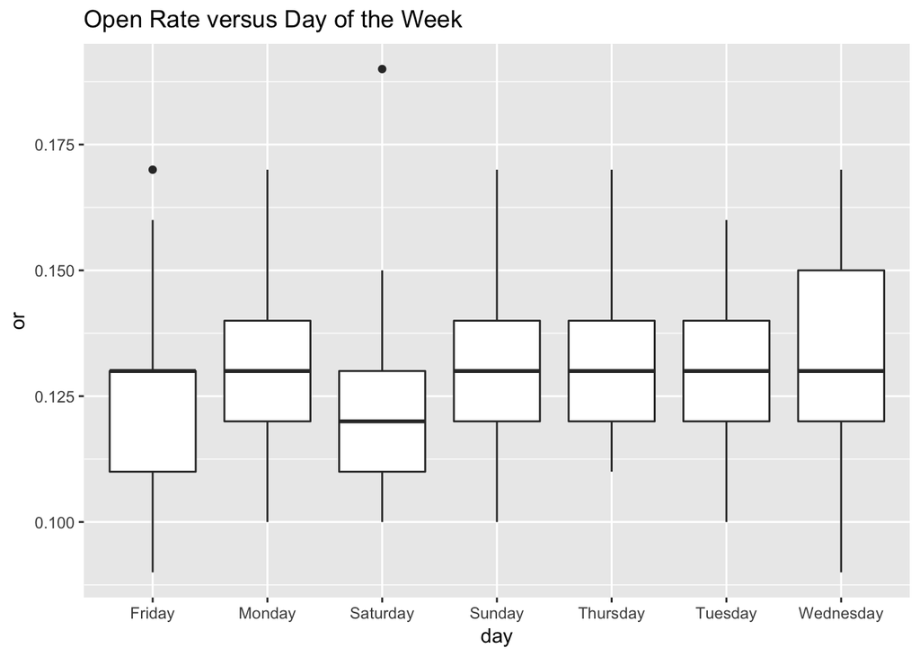

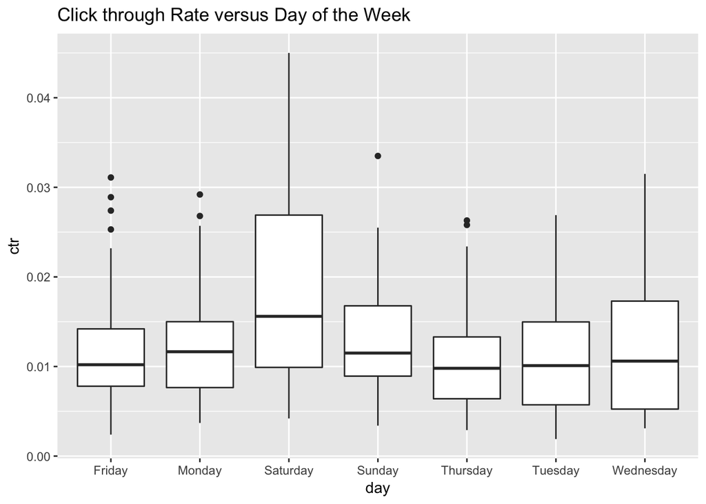

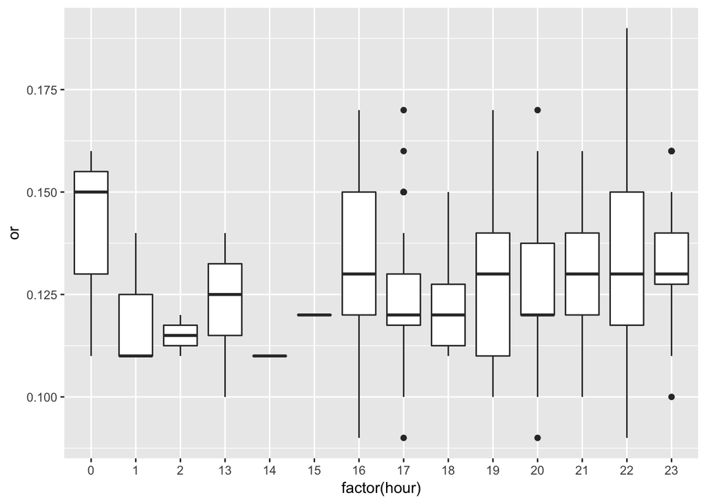

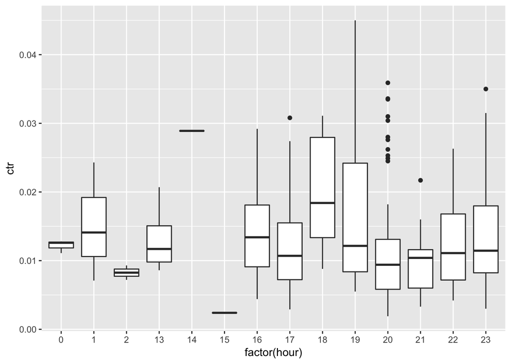

##### => Saturday and 6 pm appears to be the best time for click throuh rates - probably not statistically significant though.

### Open and click through rates over time

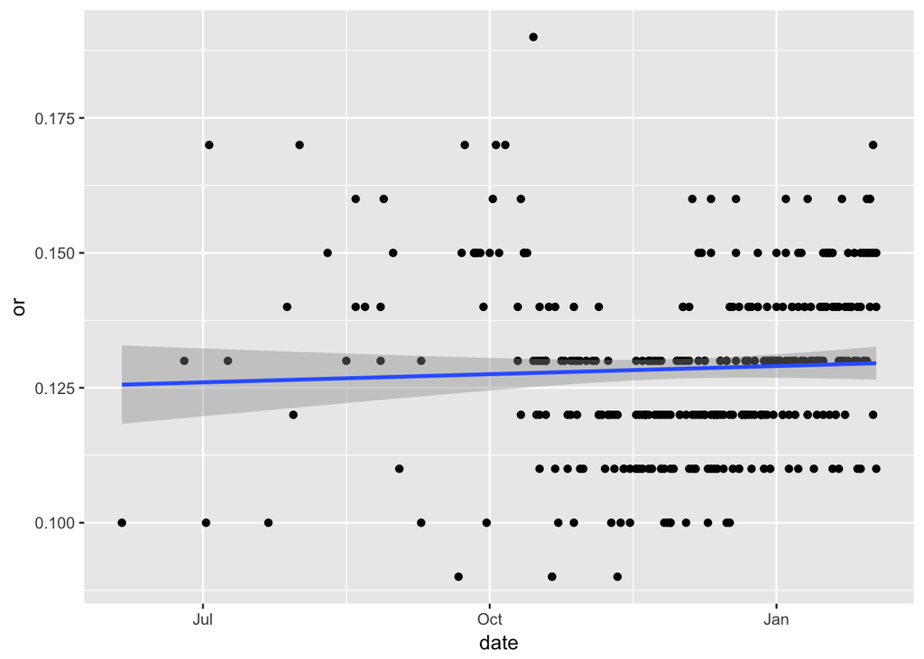

```r
# open and click throuh rates for days of the week
plot_or_time <- ggplot(camp, aes(date, or)) + geom_point() + geom_smooth(method = 'lm')
plot_or_time
```

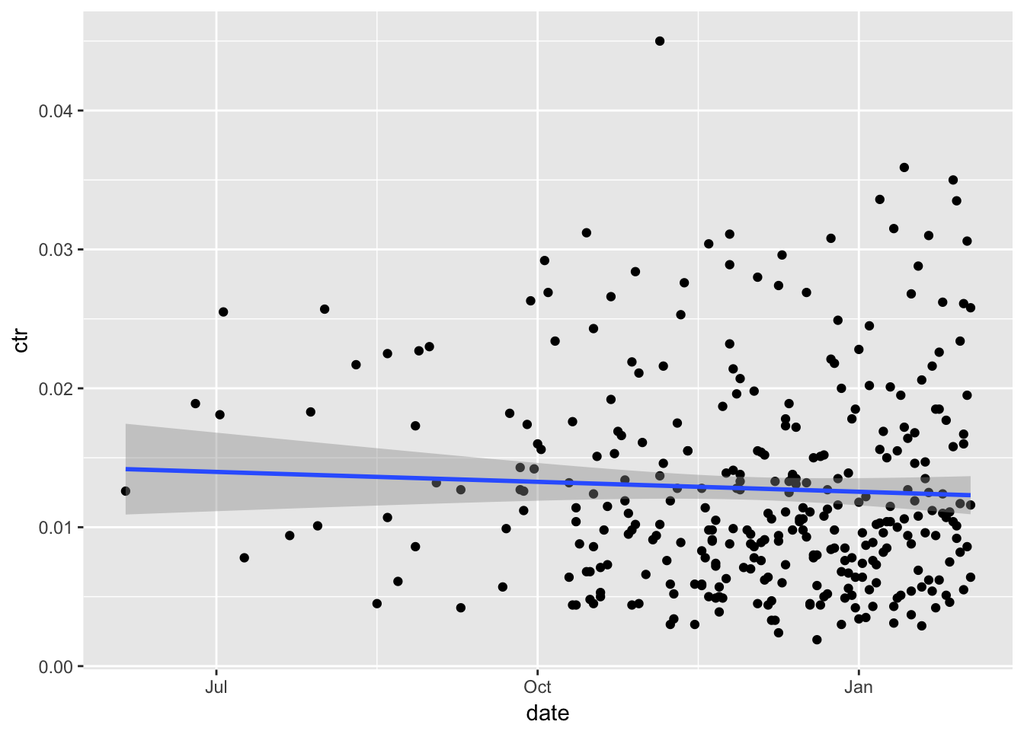

```r
plot_ctr_time <- ggplot(camp, aes(date, ctr)) + geom_point() + geom_smooth(method = 'lm')
plot_ctr_time
```

```r
# Linear models


# Setting Open Rate (or) as the dependent variable (looking at click through later)

# select variables
camp_vars_or <- select(camp, or, hour, day, length, perc_off, amt_off, off, dis, sav, lim_ed, vinyl,
                    box_set, deluxe, exclusive, new, blow, sale, steal, garage, surprise, value)

# model all  variables
mod_or_all = lm(or ~., camp_vars_or)
summary(mod_or_all)
```

```
##
## Call:
## lm(formula = or ~ ., data = camp_vars_or)
##
## Residuals:
##       Min        1Q    Median        3Q       Max
## -0.041883 -0.009814 -0.000218  0.009967  0.056165
##
## Coefficients:
##                     Estimate      Std. Error t value             Pr(>|t|)
## (Intercept)   0.130583476139  0.009858931557  13.245 < 0.0000000000000002
## hour1        -0.011897011321  0.013220713436  -0.900              0.36893
## hour2        -0.026812437115  0.014675948775  -1.827              0.06873
## hour13       -0.018530513618  0.012278544939  -1.509              0.13234
## hour14       -0.031274845540  0.018956366529  -1.650              0.10006
## hour15       -0.018348638987  0.018302964975  -1.002              0.31694
## hour16       -0.007967472819  0.009609175403  -0.829              0.40770
## hour17       -0.016227635317  0.009420716993  -1.723              0.08604
## hour18       -0.010060978830  0.011394243891  -0.883              0.37797
## hour19       -0.005867954890  0.010129102297  -0.579              0.56283
## hour20       -0.014765163685  0.009406102161  -1.570              0.11757
## hour21       -0.014865694185  0.010677894006  -1.392              0.16493
## hour22       -0.010313863122  0.009814747535  -1.051              0.29420
## hour23       -0.009306010274  0.009545021309  -0.975              0.33039
## dayMonday     0.009015531482  0.003326070714   2.711              0.00712
## daySaturday   0.004860767911  0.003544358694   1.371              0.17131
## daySunday     0.006059020086  0.003622868642   1.672              0.09552
## dayThursday   0.003646191729  0.003332341027   1.094              0.27478
## dayTuesday    0.003803582510  0.003348995748   1.136              0.25700
## dayWednesday  0.008247006914  0.003355688789   2.458              0.01457
## length        0.000084153281  0.000078324260   1.074              0.28353
## perc_off      0.000214100582  0.000130414115   1.642              0.10174
## amt_off      -0.000008465058  0.000047072549  -0.180              0.85741
## off          -0.016184644834  0.006059166560  -2.671              0.00799
## dis          -0.009908870269  0.005096404716  -1.944              0.05283
## sav           0.005066224701  0.009395450449   0.539              0.59015
## lim_ed        0.004552343061  0.003555508342   1.280              0.20144
## vinyl         0.003207937658  0.001951266627   1.644              0.10125
## box_set       0.004867077322  0.002287934639   2.127              0.03424
## deluxe        0.000329543638  0.003833881804   0.086              0.93156
```

[output cut: 38 more lines]

```
## deluxe
## exclusive
## new
## blow
## sale
## steal
## garage
## surprise     .
## value        **
## ---
## Signif. codes:  0 '***' 0.001 '**' 0.01 '*' 0.05 '.' 0.1 ' ' 1
##
## Residual standard error: 0.01545 on 290 degrees of freedom
## Multiple R-squared:  0.2469, Adjusted R-squared:  0.1508
## F-statistic:  2.57 on 37 and 290 DF,  p-value: 0.000006556
```

```r
# compile resultsd
mod_or_all_R_squared <- summary(mod_or_all)$r.squared
mod_or_all_F_value <-   summary(mod_or_all)$f[1]
mod_or_all_res <- c(mod_or_all_R_squared,mod_or_all_F_value)


# model with significant variables only
mod_or_2 = lm(or ~ day + off + dis + vinyl + sale + surprise +  value, camp_vars_or)
summary(mod_or_2)
```

```
##
## Call:
## lm(formula = or ~ day + off + dis + vinyl + sale + surprise +
##     value, data = camp_vars_or)
##
## Residuals:
##       Min        1Q    Median        3Q       Max
## -0.041306 -0.011533 -0.001339  0.011621  0.057185
##
## Coefficients:
##                     Estimate      Std. Error t value             Pr(>|t|)
## (Intercept)   0.123418853785  0.002560444557  48.202 < 0.0000000000000002
## dayMonday     0.007744055429  0.003178944718   2.436             0.015403
## daySaturday   0.004363854666  0.003464736545   1.260             0.208780
## daySunday     0.004299885088  0.003251026254   1.323             0.186920
## dayThursday   0.004466589882  0.003259219373   1.370             0.171523
## dayTuesday    0.004373776585  0.003269807263   1.338             0.181984
## dayWednesday  0.009074362926  0.003298297733   2.751             0.006281
## off          -0.009202148976  0.002506135727  -3.672             0.000283
## dis          -0.011075574709  0.004969676556  -2.229             0.026544
## vinyl         0.003946966523  0.001804992772   2.187             0.029500
## sale         -0.003126244669  0.002178283901  -1.435             0.152226
## surprise     -0.010001348534  0.005077679875  -1.970             0.049752
## value         0.000000013035  0.000000003522   3.701             0.000253
##
## (Intercept)  ***
## dayMonday    *
## daySaturday
## daySunday
## dayThursday
## dayTuesday
## dayWednesday **
## off          ***
## dis          *
## vinyl        *
## sale
## surprise     *
## value        ***
## ---
## Signif. codes:  0 '***' 0.001 '**' 0.01 '*' 0.05 '.' 0.1 ' ' 1
##
## Residual standard error: 0.0157 on 315 degrees of freedom
## Multiple R-squared:  0.1553, Adjusted R-squared:  0.1232
## F-statistic: 4.828 on 12 and 315 DF,  p-value: 0.0000002723
```

```r
# compling results
mod_or_2_R_squared <- summary(mod_or_2)$r.squared
mod_or_2_F_value <-   summary(mod_or_2)$f[1]
mod_or_2_res <- c(mod_or_2_R_squared, mod_or_2_F_value)


# model without the 'sale' variable
mod_or_3 = lm(or ~ day + off + dis + vinyl + surprise + value, camp_vars_or)
summary(mod_or_3)
```

```
##
## Call:
## lm(formula = or ~ day + off + dis + vinyl + surprise + value,
##     data = camp_vars_or)
##
## Residuals:
##       Min        1Q    Median        3Q       Max
## -0.040862 -0.011047 -0.000799  0.012247  0.058118
##
## Coefficients:
##                     Estimate      Std. Error t value             Pr(>|t|)
## (Intercept)   0.122535252543  0.002489486319  49.221 < 0.0000000000000002
## dayMonday     0.007765203377  0.003184236623   2.439             0.015293
## daySaturday   0.004298460354  0.003470241354   1.239             0.216390
## daySunday     0.004681110614  0.003245585084   1.442             0.150208
## dayThursday   0.004346478223  0.003263603496   1.332             0.183885
## dayTuesday    0.004566775690  0.003272514511   1.395             0.163847
## dayWednesday  0.009322809683  0.003299270200   2.826             0.005018
## off          -0.009192404735  0.002510325381  -3.662             0.000293
## dis          -0.010550865454  0.004964513972  -2.125             0.034341
## vinyl         0.003902494349  0.001807750471   2.159             0.031622
## surprise     -0.009245213990  0.005058734401  -1.828             0.068556
## value         0.000000013762  0.000000003491   3.942            0.0000996
##
## (Intercept)  ***
## dayMonday    *
## daySaturday
## daySunday
## dayThursday
## dayTuesday
## dayWednesday **
## off          ***
## dis          *
## vinyl        *
## surprise     .
## value        ***
## ---
## Signif. codes:  0 '***' 0.001 '**' 0.01 '*' 0.05 '.' 0.1 ' ' 1
##
## Residual standard error: 0.01572 on 316 degrees of freedom
## Multiple R-squared:  0.1498, Adjusted R-squared:  0.1202
## F-statistic: 5.062 on 11 and 316 DF,  p-value: 0.0000002719
```

```r
# compiling results
mod_or_3_R_squared <- summary(mod_or_3)$r.squared
mod_or_3_F_value <-   summary(mod_or_3)$f[1]
mod_or_3_res <- c(mod_or_3_R_squared, mod_or_3_F_value)

# compiling results from all 3 open rate - models
mod_or_res <- rbind(mod_or_all_res, mod_or_2_res, mod_or_3_res)
mod_or_res
```

```
##                             value
## mod_or_all_res 0.2468958 2.569537
## mod_or_2_res   0.1553421 4.827671
## mod_or_3_res   0.1498189 5.062321
```

```r
# Click Through Rate (ctr) ~ all

camp_vars_ctr <- select(camp, ctr, hour, day, length, perc_off, amt_off, off, dis, sav, lim_ed, vinyl,
                    box_set, deluxe, exclusive, new, blow, sale,  steal, garage, surprise, value)

mod_ctr_all = lm(ctr ~., camp_vars_ctr)
summary(mod_ctr_all)
```

```
##
## Call:
## lm(formula = ctr ~ ., data = camp_vars_ctr)
##
## Residuals:
##        Min         1Q     Median         3Q        Max
## -0.0151862 -0.0034948 -0.0004762  0.0026592  0.0213317
##
## Coefficients:
##                     Estimate      Std. Error t value             Pr(>|t|)
## (Intercept)   0.012958707024  0.003536012225   3.665             0.000294
## hour1         0.002185184200  0.004741751584   0.461             0.645260
## hour2        -0.003435668248  0.005263687447  -0.653             0.514459
## hour13        0.001614593963  0.004403832683   0.367             0.714160
## hour14        0.007641836426  0.006798905480   1.124             0.261951
## hour15       -0.006956558988  0.006564555959  -1.060             0.290156
## hour16        0.002274266442  0.003446434484   0.660             0.509848
## hour17        0.000125308109  0.003378841841   0.037             0.970442
## hour18        0.005035474408  0.004086668566   1.232             0.218883
## hour19        0.000003317514  0.003632911877   0.001             0.999272
## hour20       -0.000966312278  0.003373600074  -0.286             0.774751
## hour21       -0.002319298872  0.003829741947  -0.606             0.545253
## hour22        0.000666780179  0.003520165149   0.189             0.849898
## hour23        0.000409574291  0.003423424926   0.120             0.904852
## dayMonday     0.000291509223  0.001192931165   0.244             0.807122
## daySaturday   0.000475070394  0.001271222505   0.374             0.708892
## daySunday    -0.001387442333  0.001299380945  -1.068             0.286512
## dayThursday  -0.000968509227  0.001195180080  -0.810             0.418406
## dayTuesday   -0.000529629069  0.001201153476  -0.441             0.659590
## dayWednesday -0.000280199517  0.001203554007  -0.233             0.816073
## length       -0.000053136601  0.000028091841  -1.892             0.059550
## perc_off      0.000174576940  0.000046774430   3.732             0.000228
## amt_off       0.000025507110  0.000016883078   1.511             0.131926
## off          -0.005337660725  0.002173185492  -2.456             0.014630
## dis           0.002006283482  0.001827880564   1.098             0.273289
## sav           0.006535579932  0.003369779722   1.939             0.053414
## lim_ed       -0.001193082650  0.001275221447  -0.936             0.350263
## vinyl        -0.000741165805  0.000699842839  -1.059             0.290460
## box_set       0.002752884922  0.000820592455   3.355             0.000900
## deluxe       -0.001387414722  0.001375063094  -1.009             0.313824
```

[output cut: 38 more lines]

```
## deluxe
## exclusive    .
## new          .
## blow         ***
## sale
## steal        ***
## garage       .
## surprise     ***
## value        ***
## ---
## Signif. codes:  0 '***' 0.001 '**' 0.01 '*' 0.05 '.' 0.1 ' ' 1
##
## Residual standard error: 0.005541 on 290 degrees of freedom
## Multiple R-squared:  0.5207, Adjusted R-squared:  0.4595
## F-statistic: 8.514 on 37 and 290 DF,  p-value: < 0.00000000000000022
```

```r
# compiling results
mod_ctr_all_R_squared <- summary(mod_ctr_all)$r.squared
mod_ctr_all_F_value <-   summary(mod_ctr_all)$f[1]
mod_ctr_all_re <- c(mod_ctr_all_R_squared, mod_ctr_all_F_value)



# model after removing insignificant variables

mod_ctr_1 = lm(ctr ~ day + length + perc_off + amt_off + off + dis + vinyl + new + blow + value + steal + garage + surprise, camp_vars_ctr)
summary(mod_ctr_1)
```

```
##
## Call:
## lm(formula = ctr ~ day + length + perc_off + amt_off + off +
##     dis + vinyl + new + blow + value + steal + garage + surprise,
##     data = camp_vars_ctr)
##
## Residuals:
##       Min        1Q    Median        3Q       Max
## -0.015102 -0.003690 -0.001078  0.002907  0.021487
##
## Coefficients:
##                     Estimate      Std. Error t value             Pr(>|t|)
## (Intercept)   0.014165793265  0.001601396396   8.846 < 0.0000000000000002
## dayMonday    -0.000229155203  0.001172580413  -0.195             0.845186
## daySaturday   0.000532373160  0.001269693134   0.419             0.675294
## daySunday    -0.001591064220  0.001289348234  -1.234             0.218138
## dayThursday  -0.001361810724  0.001201179891  -1.134             0.257788
## dayTuesday   -0.000660933278  0.001196112127  -0.553             0.580959
## dayWednesday -0.000618508745  0.001207978397  -0.512             0.609003
## length       -0.000056795458  0.000026586912  -2.136             0.033447
## perc_off      0.000201724556  0.000044440728   4.539          0.000008099
## amt_off       0.000034375916  0.000016670577   2.062             0.040037
## off          -0.006147460456  0.002077784315  -2.959             0.003328
## dis           0.001814308087  0.001820213182   0.997             0.319663
## vinyl        -0.001205555697  0.000686648596  -1.756             0.080129
## new          -0.001161157052  0.000893171708  -1.300             0.194557
## blow          0.007555782254  0.001721586709   4.389          0.000015660
## value         0.000000007014  0.000000001300   5.396          0.000000136
## steal         0.006880242092  0.001827276011   3.765             0.000199
## garage        0.003886497049  0.002141196010   1.815             0.070477
## surprise      0.016805749594  0.001854427879   9.062 < 0.0000000000000002
##
## (Intercept)  ***
## dayMonday
## daySaturday
## daySunday
## dayThursday
## dayTuesday
## dayWednesday
## length       *
## perc_off     ***
## amt_off      *
## off          **
## dis
## vinyl        .
## new
## blow         ***
## value        ***
## steal        ***
## garage       .
## surprise     ***
## ---
## Signif. codes:  0 '***' 0.001 '**' 0.01 '*' 0.05 '.' 0.1 ' ' 1
##
## Residual standard error: 0.005719 on 309 degrees of freedom
## Multiple R-squared:  0.4558, Adjusted R-squared:  0.4241
## F-statistic: 14.38 on 18 and 309 DF,  p-value: < 0.00000000000000022
```

```r
# compiling results
mod_ctr_1_R_squared <- summary(mod_ctr_1)$r.squared
mod_ctr_1_F_value <-   summary(mod_ctr_1)$f[1]
mod_ctr_1_res = c(mod_ctr_1_R_squared, mod_ctr_1_F_value)



# model without the insignificant variables

mod_ctr_2 = lm(ctr ~  length + perc_off + amt_off + off + dis  + blow + value + steal + surprise, camp_vars_ctr)
summary(mod_ctr_2)
```

```
##
## Call:
## lm(formula = ctr ~ length + perc_off + amt_off + off + dis +
##     blow + value + steal + surprise, data = camp_vars_ctr)
##
## Residuals:
##       Min        1Q    Median        3Q       Max
## -0.015857 -0.004026 -0.000895  0.003237  0.021115
##
## Coefficients:
##                    Estimate      Std. Error t value             Pr(>|t|)
## (Intercept)  0.013507565317  0.001358112299   9.946 < 0.0000000000000002
## length      -0.000068646177  0.000025790089  -2.662              0.00817
## perc_off     0.000213294503  0.000044239835   4.821          0.000002214
## amt_off      0.000036530808  0.000016555187   2.207              0.02806
## off         -0.006131625157  0.002074232507  -2.956              0.00335
## dis          0.001975256569  0.001821981494   1.084              0.27913
## blow         0.008159844834  0.001703444366   4.790          0.000002559
## value        0.000000006708  0.000000001277   5.255          0.000000272
## steal        0.006423364859  0.001602023233   4.010          0.000075865
## surprise     0.018299926580  0.001649622014  11.093 < 0.0000000000000002
##
## (Intercept) ***
## length      **
## perc_off    ***
## amt_off     *
## off         **
## dis
## blow        ***
## value       ***
## steal       ***
## surprise    ***
## ---
## Signif. codes:  0 '***' 0.001 '**' 0.01 '*' 0.05 '.' 0.1 ' ' 1
##
## Residual standard error: 0.005751 on 318 degrees of freedom
## Multiple R-squared:  0.4338, Adjusted R-squared:  0.4177
## F-statistic: 27.07 on 9 and 318 DF,  p-value: < 0.00000000000000022
```

```r
mod_ctr_2_R_squared <- summary(mod_ctr_2)$r.squared
mod_ctr_2_F_value <-   summary(mod_ctr_2)$f[1]
mod_ctr_2_res <-  c(mod_ctr_2_R_squared, mod_ctr_2_F_value)

# removing discoung variable that's now insignificant

mod_ctr_3 = lm(ctr ~  length + perc_off + amt_off + off +  blow + value + steal + surprise, camp_vars_ctr)
summary(mod_ctr_3)
```

```
##
## Call:
## lm(formula = ctr ~ length + perc_off + amt_off + off + blow +
##     value + steal + surprise, data = camp_vars_ctr)
##
## Residuals:
##        Min         1Q     Median         3Q        Max
## -0.0165683 -0.0039723 -0.0009017  0.0032190  0.0210324
##
## Coefficients:
##                    Estimate      Std. Error t value             Pr(>|t|)
## (Intercept)  0.013401350365  0.001354946050   9.891 < 0.0000000000000002
## length      -0.000065277798  0.000025609285  -2.549              0.01127
## perc_off     0.000212823581  0.000044249858   4.810          0.000002336
## amt_off      0.000036353457  0.000016558927   2.195              0.02885
## off         -0.006152656149  0.002074711705  -2.966              0.00325
## blow         0.008109039973  0.001703267520   4.761          0.000002929
## value        0.000000006635  0.000000001275   5.203          0.000000351
## steal        0.006399632206  0.001602313808   3.994          0.000080706
## surprise     0.018918372721  0.001548272995  12.219 < 0.0000000000000002
##
## (Intercept) ***
## length      *
## perc_off    ***
## amt_off     *
## off         **
## blow        ***
## value       ***
## steal       ***
## surprise    ***
## ---
## Signif. codes:  0 '***' 0.001 '**' 0.01 '*' 0.05 '.' 0.1 ' ' 1
##
## Residual standard error: 0.005753 on 319 degrees of freedom
## Multiple R-squared:  0.4317, Adjusted R-squared:  0.4174
## F-statistic: 30.29 on 8 and 319 DF,  p-value: < 0.00000000000000022
```

```r
mod_ctr_3_R_squared <- summary(mod_ctr_3)$r.squared
mod_ctr_3_F_value <-   summary(mod_ctr_3)$f[1]
mod_ctr_3_res <-  c(mod_ctr_3_R_squared, mod_ctr_3_F_value)


# Comparing all three Click Through Rate models:
mod_ctr_res = rbind(mod_ctr_all_re, mod_ctr_1_res,mod_ctr_2_res, mod_ctr_3_res)
```

### Best Model:

```
##
## Call:
## lm(formula = ctr ~ length + perc_off + amt_off + off + blow +
##     value + steal + surprise, data = camp_vars_ctr)
##
## Residuals:
##        Min         1Q     Median         3Q        Max
## -0.0165683 -0.0039723 -0.0009017  0.0032190  0.0210324
##
## Coefficients:
##                    Estimate      Std. Error t value             Pr(>|t|)
## (Intercept)  0.013401350365  0.001354946050   9.891 < 0.0000000000000002
## length      -0.000065277798  0.000025609285  -2.549              0.01127
## perc_off     0.000212823581  0.000044249858   4.810          0.000002336
## amt_off      0.000036353457  0.000016558927   2.195              0.02885
## off         -0.006152656149  0.002074711705  -2.966              0.00325
## blow         0.008109039973  0.001703267520   4.761          0.000002929
## value        0.000000006635  0.000000001275   5.203          0.000000351
## steal        0.006399632206  0.001602313808   3.994          0.000080706
## surprise     0.018918372721  0.001548272995  12.219 < 0.0000000000000002
##
## (Intercept) ***
## length      *
## perc_off    ***
## amt_off     *
## off         **
## blow        ***
## value       ***
## steal       ***
## surprise    ***
## ---
## Signif. codes:  0 '***' 0.001 '**' 0.01 '*' 0.05 '.' 0.1 ' ' 1
##
## Residual standard error: 0.005753 on 319 degrees of freedom
## Multiple R-squared:  0.4317, Adjusted R-squared:  0.4174
## F-statistic: 30.29 on 8 and 319 DF,  p-value: < 0.00000000000000022
```

### Preliminary Conclusion:

Maybe we should seprate Artist specific campaigns and general campaigns. The former might appeal to a smaller audience, producing lower open and click through rates, but higher conversion. The latter may will apeal to a broader audience and be associtated with higher open and click through rates, but lower conversion. To be continued.